# Lab 15 Sarah

Sarah Liddle

May 1, 2018

## Freedom and Happiness

In this section, we will analyze how freedom will affect a general country’s happiness. The freedom category of the dataset represents the extent to which freedom contributed to the overall happiness score of the country.

First we will use a permuation hypothesis test to see if there was a significant difference in the freedom contribution for the ten happiest countries. This is done by taking a thousand random samples of the average of ten freedom contributions, and comparing the mean of the top ten with this distribution overall.

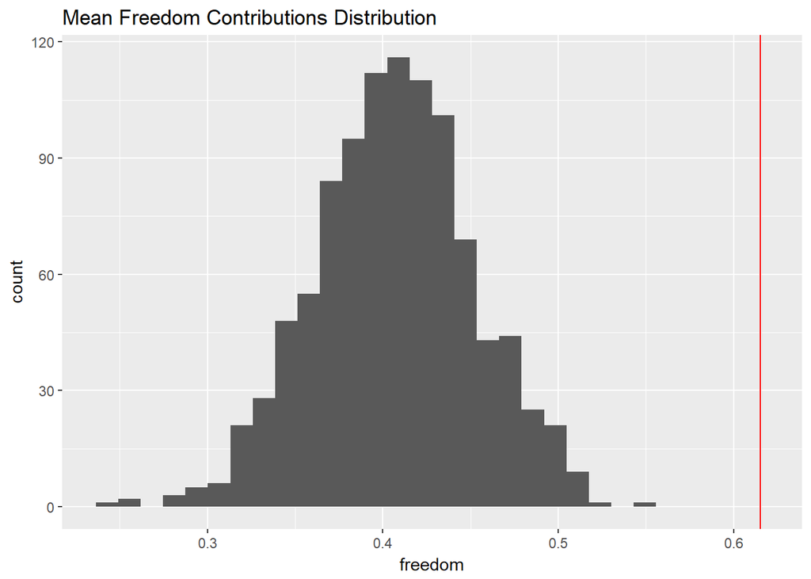

```
## [1] 1
```

As one can see, there is indeed a significant difference between the freedom contribution in the top ten happiest countries and the rest of the countries. This suggests that freedom has a significant impact on a country’s happiness.

To further this analysis, we will perform linear regression on the relationship between the freedom contribution and the happiness scores for each country.

```
##
## Call:
## lm(formula = Happiness.Score ~ Freedom, data = happiness)
##
## Residuals:
##      Min       1Q   Median       3Q      Max
## -2.62713 -0.66167  0.08347  0.78087  1.87101
##
## Coefficients:
##             Estimate Std. Error t value Pr(>|t|)
## (Intercept)   3.5963     0.2180  16.495  < 2e-16 ***
## Freedom       4.2998     0.5009   8.584 9.69e-15 ***
## ---
## Signif. codes:  0 '***' 0.001 '**' 0.01 '*' 0.05 '.' 0.1 ' ' 1
##
## Residual standard error: 0.9324 on 153 degrees of freedom
## Multiple R-squared:  0.3251, Adjusted R-squared:  0.3206
## F-statistic: 73.69 on 1 and 153 DF,  p-value: 9.688e-15
```

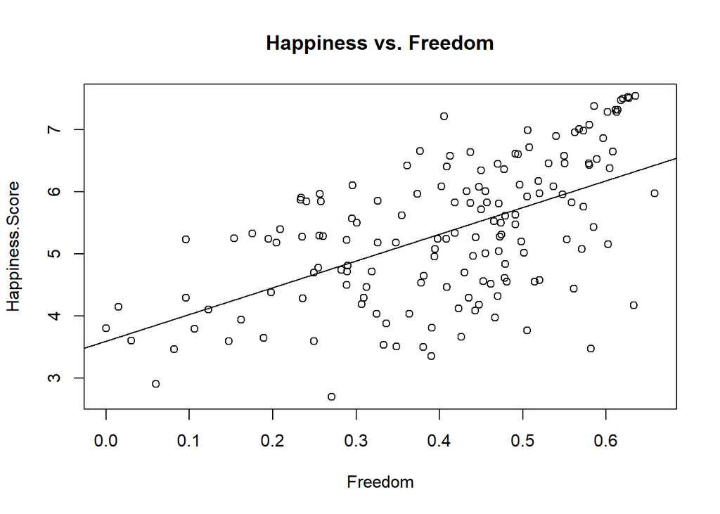

The linear model suggests that for every unit increase in the freedom contribution, the happiness score will increase by 4.3 on average, and that a country with no freedom contribution will have an estimated happiness score of 3.596. Both these pieces of the linear model are significant. However, this linear model only accounts for 32.5% of the variation in the happiness scores, so we will examine other factors as well.

## Goal Reflection

The goals I set for myself for six months and five years after graduation haven’t really changed all that much with this semester. I still am hoping to graduate next year with a major in math and a focus in data science and statistics, along with a minor in creative writing. After that, I still hope to be exploring a variety of jobs or projects within jobs and getting a feel for what I might like. I also might consider getting a Masters after I get a little more experience in industry to get a better feel for what really makes me happy. I have an internship working with data this summer, and I’m hoping that will really help me solidify some goals as well.

## Summary of Individual Contributions

Sarah: I used permutation hypothesis testing to analyze whether there was a significant difference in the mean of the ten happiest countries’ freedom contribution as compared with the rest of the data. I also used linear regression to determine the relationship between freedom and happiness. Finally, I reflected on the goals I set for myself during the beginning of the semester.